# Project Python Foundations: FoodHub Data Analysis

### Context

The number of restaurants in New York is increasing day by day. Lots of students and busy professionals rely on those restaurants due to their hectic lifestyles. Online food delivery service is a great option for them. It provides them with good food from their favorite restaurants. A food aggregator company FoodHub offers access to multiple restaurants through a single smartphone app.

The app allows the restaurants to receive a direct online order from a customer. The app assigns a delivery person from the company to pick up the order after it is confirmed by the restaurant. The delivery person then uses the map to reach the restaurant and waits for the food package. Once the food package is handed over to the delivery person, he/she confirms the pick-up in the app and travels to the customer's location to deliver the food. The delivery person confirms the drop-off in the app after delivering the food package to the customer. The customer can rate the order in the app. The food aggregator earns money by collecting a fixed margin of the delivery order from the restaurants.

### Objective

The food aggregator company has stored the data of the different orders made by the registered customers in their online portal. They want to analyze the data to get a fair idea about the demand of different restaurants which will help them in enhancing their customer experience. Suppose you are hired as a Data Scientist in this company and the Data Science team has shared some of the key questions that need to be answered. Perform the data analysis to find answers to these questions that will help the company to improve the business.

### Data Description

The data contains the different data related to a food order. The detailed data dictionary is given below.

### Data Dictionary

- order_id: Unique ID of the order
- customer_id: ID of the customer who ordered the food
- restaurant_name: Name of the restaurant
- cuisine_type: Cuisine ordered by the customer
- cost_of_the_order: Cost of the order
- day_of_the_week: Indicates whether the order is placed on a weekday or weekend (The weekday is from Monday to Friday and the weekend is Saturday and Sunday)
- rating: Rating given by the customer out of 5
- food_preparation_time: Time (in minutes) taken by the restaurant to prepare the food. This is calculated by taking the difference between the timestamps of the restaurant's order confirmation and the delivery person's pick-up confirmation.
- delivery_time: Time (in minutes) taken by the delivery person to deliver the food package. This is calculated by taking the difference between the timestamps of the delivery person's pick-up confirmation and drop-off information

### Let us start by importing the required libraries

```python
# Installing the libraries with the specified version.
!pip install numpy==1.25.2 pandas==1.5.3 matplotlib==3.7.1 seaborn==0.13.1 -q --user
```

**Note**: *After running the above cell, kindly restart the notebook kernel and run all cells sequentially from the start again.*

```python
# import libraries for data manipulation
import numpy as np
import pandas as pd

# import libraries for data visualization
import matplotlib.pyplot as plt
import seaborn as sns

import warnings

# to restrict the float value to 3 decimal places
pd.set_option('display.float_format', lambda x: '%.3f' % x)
```

### Understanding the structure of the data

```python
from google.colab import drive
drive.mount('/content/drive')
```

```python
data= pd.read_csv('/content/drive/MyDrive/Colab Notebooks/Project_1/foodhub_order.csv')
```

```python
#To ignore the warnings
warnings.filterwarnings("ignore")
```

```python
data.head()
```

|  | order_id | customer_id | restaurant_name | cuisine_type | cost_of_the_order | day_of_the_week | rating | food_preparation_time | delivery_time |
| --- | --- | --- | --- | --- | --- | --- | --- | --- | --- |
| 0 | 1477147 | 337525 | Hangawi | Korean | 30.750 | Weekend | Not given | 25 | 20 |
| 1 | 1477685 | 358141 | Blue Ribbon Sushi Izakaya | Japanese | 12.080 | Weekend | Not given | 25 | 23 |
| 2 | 1477070 | 66393 | Cafe Habana | Mexican | 12.230 | Weekday | 5 | 23 | 28 |
| 3 | 1477334 | 106968 | Blue Ribbon Fried Chicken | American | 29.200 | Weekend | 3 | 25 | 15 |
| 4 | 1478249 | 76942 | Dirty Bird to Go | American | 11.590 | Weekday | 4 | 25 | 24 |

### **Question 1:** How many rows and columns are present in the data? [0.5 mark]

```python
print("There are",data.shape[0],"rows and ",data.shape[1],"columns.")
```

```
There are 1898 rows and  9 columns.
```

### **Question 2:** What are the datatypes of the different columns in the dataset? (The info() function can be used) [0.5 mark]

```python
data.info()
```

```
<class 'pandas.core.frame.DataFrame'>
RangeIndex: 1898 entries, 0 to 1897
Data columns (total 9 columns):
 #   Column                 Non-Null Count  Dtype
---  ------                 --------------  -----
 0   order_id               1898 non-null   int64
 1   customer_id            1898 non-null   int64
 2   restaurant_name        1898 non-null   object
 3   cuisine_type           1898 non-null   object
 4   cost_of_the_order      1898 non-null   float64
 5   day_of_the_week        1898 non-null   object
 6   rating                 1898 non-null   object
 7   food_preparation_time  1898 non-null   int64
 8   delivery_time          1898 non-null   int64
dtypes: float64(1), int64(4), object(4)
memory usage: 133.6+ KB
```

#### Observations:

- 1 column of type float64
- 4 columns of type int64,
- 4 columns of type object

### **Question 3:** Are there any missing values in the data? If yes, treat them using an appropriate method. [1 mark]

```python
#to check whether there are any null values present we use isnull() and sum() is used to calculate the total number of null values in each column if present
data.isnull().sum()
```

|  | 0 |
| --- | --- |
| order_id | 0 |
| customer_id | 0 |
| restaurant_name | 0 |
| cuisine_type | 0 |
| cost_of_the_order | 0 |
| day_of_the_week | 0 |
| rating | 0 |
| food_preparation_time | 0 |
| delivery_time | 0 |

**dtype:** int64

Observations: No null values

### **Question 4:** Check the statistical summary of the data. What is the minimum, average, and maximum time it takes for food to be prepared once an order is placed? [2 marks]

```python
#describe() is used to get the statistical summary of data.We have assigned the value 'all' to include parameter to get the description of all types of data.
#The default decribe() gives only the data of numerical columns
data.describe( include='all').T
```

|  | count | unique | top | freq | mean | std | min | 25% | 50% | 75% | max |
| --- | --- | --- | --- | --- | --- | --- | --- | --- | --- | --- | --- |
| order_id | 1898.000 | NaN | NaN | NaN | 1477495.500 | 548.050 | 1476547.000 | 1477021.250 | 1477495.500 | 1477969.750 | 1478444.000 |
| customer_id | 1898.000 | NaN | NaN | NaN | 171168.478 | 113698.140 | 1311.000 | 77787.750 | 128600.000 | 270525.000 | 405334.000 |
| restaurant_name | 1898 | 178 | Shake Shack | 219 | NaN | NaN | NaN | NaN | NaN | NaN | NaN |
| cuisine_type | 1898 | 14 | American | 584 | NaN | NaN | NaN | NaN | NaN | NaN | NaN |
| cost_of_the_order | 1898.000 | NaN | NaN | NaN | 16.499 | 7.484 | 4.470 | 12.080 | 14.140 | 22.297 | 35.410 |
| day_of_the_week | 1898 | 2 | Weekend | 1351 | NaN | NaN | NaN | NaN | NaN | NaN | NaN |
| rating | 1898 | 4 | Not given | 736 | NaN | NaN | NaN | NaN | NaN | NaN | NaN |
| food_preparation_time | 1898.000 | NaN | NaN | NaN | 27.372 | 4.632 | 20.000 | 23.000 | 27.000 | 31.000 | 35.000 |
| delivery_time | 1898.000 | NaN | NaN | NaN | 24.162 | 4.973 | 15.000 | 20.000 | 25.000 | 28.000 | 33.000 |

```python
print("Minimum time taken for food to be propered once the order is placed = ",data['food_preparation_time'].min(),"minutes")
print("Average time taken for food to be propered once the order is placed = ",data['food_preparation_time'].mean().round(3),"minutes")
print("Maximum time taken for food to be propered once the order is placed = ",data['food_preparation_time'].max(),"minutes")
```

```
Minimum time taken for food to be propered once the order is placed =  20 minutes
Average time taken for food to be propered once the order is placed =  27.372 minutes
Maximum time taken for food to be propered once the order is placed =  35 minutes
```

### **Question 5:** How many orders are not rated? [1 mark]

```python
data['rating'].value_counts()
```

| rating | count |
| --- | --- |
| Not given | 736 |
| 5 | 588 |
| 4 | 386 |
| 3 | 188 |

**dtype:** int64

```python
print("No of orders that are not rated =",data['rating'].value_counts()['Not given'])
```

```
No of orders that are not rated = 736
```

### Exploratory Data Analysis (EDA)

### **Question 6:** Explore all the variables and provide observations on their distributions. (Generally, histograms, boxplots, countplots, etc. are used for univariate exploration.) [9 marks]

```python
print("Total number of orders = ",data.shape[0])
print("Total number of restaurants = ",data['restaurant_name'].nunique())
print("Total number of customers = ",data['customer_id'].nunique())
print("Total number of cuisine types = ",data['cuisine_type'].nunique())
```

```
Total number of orders =  1898
Total number of restaurants =  178
Total number of customers =  1200
Total number of cuisine types =  14
```

# Observations on orders placed by different customer ids

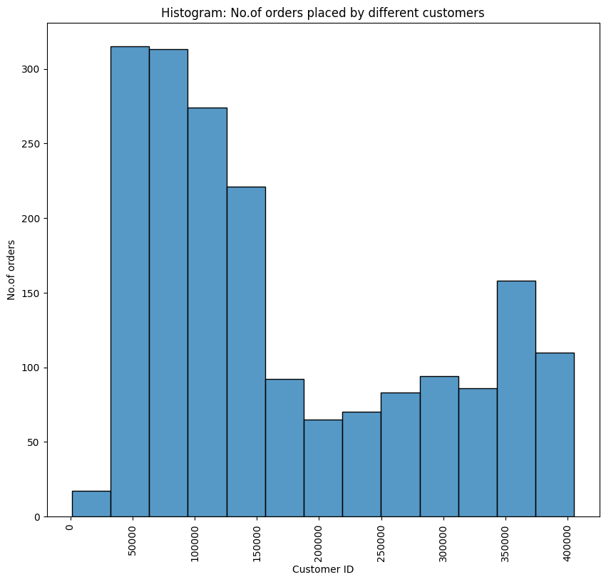

```python
plt.figure(figsize=(10,9))
plt.title('Histogram: No.of orders placed by different customers')
sns.histplot(data =data,x = 'customer_id')
plt.xlabel('Customer ID')
plt.ylabel('No.of orders')
plt.xticks(rotation =90);
plt.show()
```

```python
data['customer_id'].value_counts()
```

| customer_id | count |
| --- | --- |
| 52832 | 13 |
| 47440 | 10 |
| 83287 | 9 |
| 250494 | 8 |
| 259341 | 7 |
| ... | ... |
| 385426 | 1 |
| 254913 | 1 |
| 289597 | 1 |
| 74412 | 1 |
| 397537 | 1 |

1200 rows × 1 columns

**dtype:** int64

# Observations:

- There are almost 1200 customers
- Customer with customer id 52832 has placed the most no of orders,followed by the customers with the customer id 47440 and 83287
- We can also see that majority of the orders are placed with IDS in the lower range.The number of orders placed decreases when the range of IDs increase.If the ids are sequential IDs,it shows that majority of the orders are placed by the customers who joined the app earlier

# Observations on Number of orders per restaurant

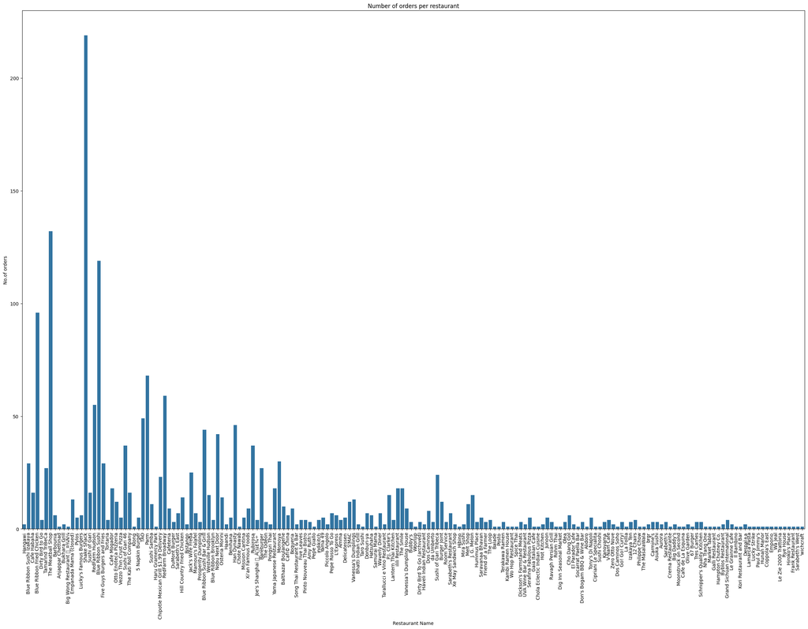

```python
plt.figure(figsize=(30,20))
plt.title('Number of orders per restaurant')
plt.xlabel('Restaurant Name')
plt.ylabel('No.of orders')
sns.countplot(data =data,x = 'restaurant_name')
plt.xticks(rotation =90);
plt.show();
```

```python
data['restaurant_name'].value_counts()
```

| restaurant_name | count |
| --- | --- |
| Shake Shack | 219 |
| The Meatball Shop | 132 |
| Blue Ribbon Sushi | 119 |
| Blue Ribbon Fried Chicken | 96 |
| Parm | 68 |
| ... | ... |
| Sushi Choshi | 1 |
| Dos Caminos Soho | 1 |
| La Follia | 1 |
| Philippe Chow | 1 |
| 'wichcraft | 1 |

178 rows × 1 columns

**dtype:** int64

# Observations:

- Total number of restaurants = 178
- Shake Shack has received the highest number of orders(219),followed by 'The Meatball Shop and Blue Ribbon Sushi.
- We can see that plot is heavily skewed with some of the restaurants being really popular and some being the least favourite.

# Observations on Cuisine Type

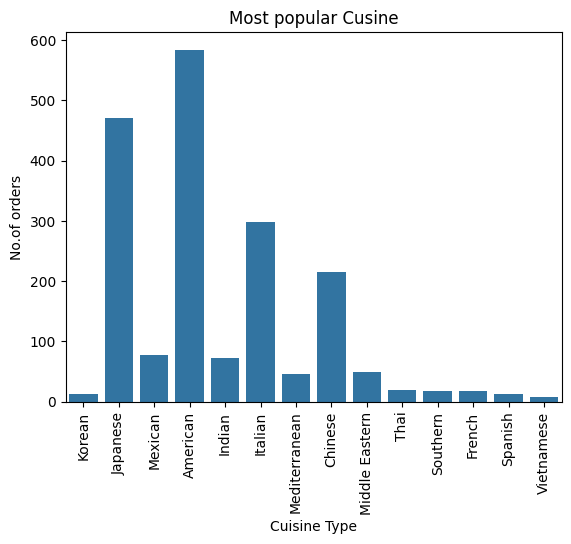

```python
plt.title('Most popular Cusine')
plt.xlabel('Cuisine Type')
plt.ylabel('No.of orders')
sns.countplot(data =data,x = 'cuisine_type')
plt.xticks(rotation =90);
plt.show()
```

```python
data['cuisine_type'].value_counts()
```

| cuisine_type | count |
| --- | --- |
| American | 584 |
| Japanese | 470 |
| Italian | 298 |
| Chinese | 215 |
| Mexican | 77 |
| Indian | 73 |
| Middle Eastern | 49 |
| Mediterranean | 46 |
| Thai | 19 |
| French | 18 |
| Southern | 17 |
| Korean | 13 |
| Spanish | 12 |
| Vietnamese | 7 |

**dtype:** int64

Observations :

- Total no of cuisine types = 14
- American cuisine is the most ordered cusine,followed by Japanese and Italian

# Observations on cost of order

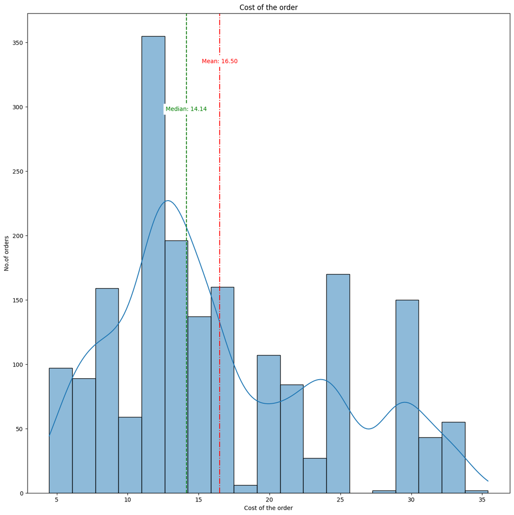

```python
plt.figure(figsize=(15,15))
plt.title('Cost of the order')
plt.xlabel('Cost of the order')
plt.ylabel('No.of orders')
ax=sns.histplot(data = data,x = 'cost_of_the_order',kde= True);

mean_value = data['cost_of_the_order'].mean()
median_value = data['cost_of_the_order'].median()

#Add vertical line to the plot to highlight mean
plt.axvline(data['cost_of_the_order'].mean(),label= 'mean',color = 'red',linestyle = '-.');
plt.text(mean_value, plt.ylim()[1] * 0.9, f'Mean: {mean_value:.2f}',color='red', ha='center', va='center', backgroundcolor='white')

#Add vertical line to the plot to highlight median
plt.axvline(data['cost_of_the_order'].median(),label = 'median',color = 'green',linestyle = '--');
plt.text(median_value, plt.ylim()[1] * 0.8, f'Median: {median_value :.2f}',color='green', ha='center', va='center', backgroundcolor='white')
plt.show();
```

```python
data['cost_of_the_order'].describe()
```

|  | cost_of_the_order |
| --- | --- |
| count | 1898.000 |
| mean | 16.499 |
| std | 7.484 |
| min | 4.470 |
| 25% | 12.080 |
| 50% | 14.140 |
| 75% | 22.297 |
| max | 35.410 |

**dtype:** float64

```python
data['cost_of_the_order'].value_counts()
```

| cost_of_the_order | count |
| --- | --- |
| 12.180 | 86 |
| 12.130 | 82 |
| 12.230 | 47 |
| 24.200 | 42 |
| 29.100 | 37 |
| ... | ... |
| 5.480 | 1 |
| 17.070 | 1 |
| 6.260 | 1 |
| 9.610 | 1 |
| 29.590 | 1 |

312 rows × 1 columns

**dtype:** int64

```python
# Restaurant that had the highest cost of the order
data.loc[data['cost_of_the_order']==35.41]
```

|  | order_id | customer_id | restaurant_name | cuisine_type | cost_of_the_order | day_of_the_week | rating | food_preparation_time | delivery_time |
| --- | --- | --- | --- | --- | --- | --- | --- | --- | --- |
| 573 | 1477814 | 62359 | Pylos | Mediterranean | 35.410 | Weekday | 4 | 21 | 29 |

# **Obervations:**

- Cost of the order is positively skewed.Here as the cost of the order increases,the count decreases
- Min value of cost of order is 4.47 and max value is 35.41
- Median of the cost of the oder is 14.140,while mean is 16.49
- Cost of the orders most preferred by the customer is 12.180
- Cost of the orders is within the range 4-36
- The restaurant 'Pylos' had the highest cost of the order

# Lets see the trend of number of orders placed in the day of the week

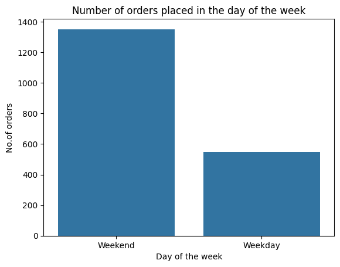

```python
plt.title('Number of orders placed in the day of the week')
plt.xlabel('Day of the week')
plt.ylabel('No.of orders')
sns.countplot(data =data,x = 'day_of_the_week')
plt.show()
```

```python
#Number of orders placed during weekend and weekday
data['day_of_the_week'].value_counts()
```

| day_of_the_week | count |
| --- | --- |
| Weekend | 1351 |
| Weekday | 547 |

**dtype:** int64

```python
print("Total number of orders placed = ",data.shape[0])
print("Total of number of orders placed on weekends = ",data['day_of_the_week'].value_counts()['Weekend'])
print("Percentage of number of orders placed on weekends = ",data['day_of_the_week'].value_counts()['Weekend']/data.shape[0]*100,"%")
```

```
Total number of orders placed =  1898
Total of number of orders placed on weekends =  1351
Percentage of number of orders placed on weekends =  71.18018967334035 %
```

# Observations:

- Total number of orders placed in the app is 1898
- The number of orders placed during weekends is 71.18% of total number of orders placed.ie Majority of the orders on the app is placed during the weekends

# Observations on ratings

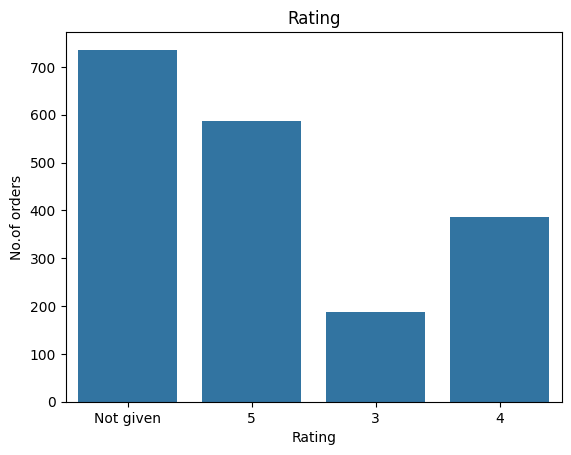

```python
plt.title('Rating')
plt.xlabel('Rating')
plt.ylabel('No.of orders')
sns.countplot(data =data,x = 'rating')
plt.show()
```

```python
# Ratings available
data['rating'].value_counts()
```

| rating | count |
| --- | --- |
| Not given | 736 |
| 5 | 588 |
| 4 | 386 |
| 3 | 188 |

**dtype:** int64

## Observations:

About 736 of the orders are not rated and the value of those ratings is given as 'Not given'.ie 38% of the orders are not given any ratings

```python
#To calculate the average of the ratings made we need to create a data with only rated values.For this we are deleting the rows with no ratings givenAlso changing the type of rating to int
#We are doing the modifications of the rating after copying the original data to another dataframe so that the original dataframe is not manipulated
new_data = data.copy()
new_data = new_data[new_data['rating'] != 'Not given']
new_data['rating'] = new_data['rating'].astype(int)
```

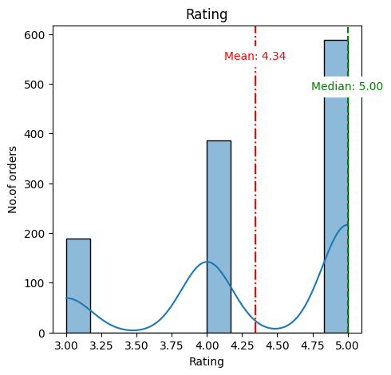

```python
plt.figure(figsize=(5,5))
plt.title('Rating')
plt.xlabel('Rating')
plt.ylabel('No.of orders')
sns.histplot(data = new_data,x = 'rating',kde= True);

mean_value = new_data['rating'].mean()
#Add vertical line to the plot to highlight mean
plt.axvline(new_data['rating'].mean(),label = 'mean',color = 'red',linestyle = '-.');
plt.text(mean_value, plt.ylim()[1] * 0.9, f'Mean: {mean_value:.2f}',color='red', ha='center', va='center', backgroundcolor='white')

median_value = new_data['rating'].median()
#Add vertical line to the plot to highlight median
plt.axvline(new_data['rating'].median(),label = 'median',color = 'green',linestyle = '--');
plt.text(median_value, plt.ylim()[1] * 0.8, f'Median: {median_value:.2f}',color='green', ha='center', va='center', backgroundcolor='white')
plt.show();
```

```python
new_data['rating'].describe()
```

|  | rating |
| --- | --- |
| count | 1162.000 |
| mean | 4.344 |
| std | 0.741 |
| min | 3.000 |
| 25% | 4.000 |
| 50% | 5.000 |
| 75% | 5.000 |
| max | 5.000 |

**dtype:** float64

# Observations:

- Rating is negatively /left skewed with the mean around 4.3 and median at 5.ie Median>Mean.
- Mean value of the rating is around 4.3 and the median is 5
- Most of the ratings are on the higher side
- Peak at 5 indicated that customers are mostly satisfied
- All these observations are based on the ratings given by the customers.Almost 38% of the orders are not given ratings.So we cannot be sure the same will be the scenario if all the orders were rated

## Observations on food_preparation_time

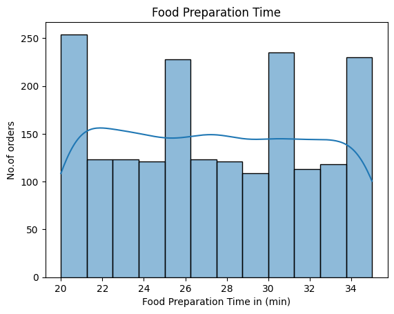

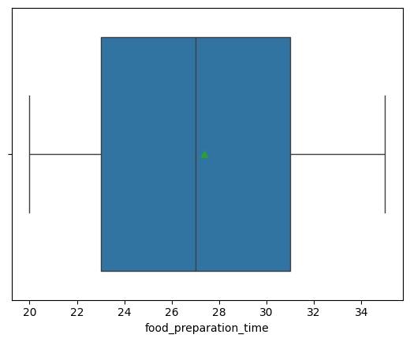

```python
plt.title('Food Preparation Time')
plt.xlabel('Food Preparation Time in (min)')
plt.ylabel('No.of orders')
sns.histplot(data = data,x = 'food_preparation_time',kde= True);
plt.show();
sns.boxplot(data = data,x = 'food_preparation_time',showmeans = True);
plt.show();
```

```python
data['food_preparation_time'].describe()
```

|  | food_preparation_time |
| --- | --- |
| count | 1898.000 |
| mean | 27.372 |
| std | 4.632 |
| min | 20.000 |
| 25% | 23.000 |
| 50% | 27.000 |
| 75% | 31.000 |
| max | 35.000 |

**dtype:** float64

Observations:

- Minimum Food Preparation time = 20 min
- Maximum Food Preparation time = 35 min
- Mean of Food Preparation time = 27.372 min
- Median of Food Preparation time = 27 min
- Food_preparation_time peaks around 20,26,30,34.Indicating that most of the orders placed have that food preparation time

# Let us analyse the spread of delivery_time

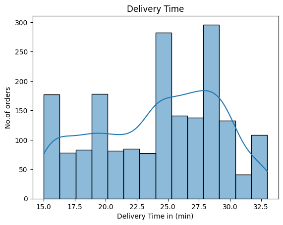

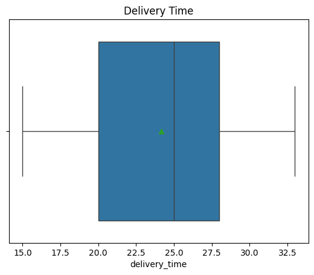

```python
plt.title('Delivery Time')
sns.histplot(data = data,x = 'delivery_time',kde= True);
plt.xlabel('Delivery Time in (min)')
plt.ylabel('No.of orders')
plt.show()

#Boxplot
plt.title('Delivery Time')
sns.boxplot(data = data,x = 'delivery_time',showmeans = True);
```

```python
data['delivery_time'].describe()
```

|  | delivery_time |
| --- | --- |
| count | 1898.000 |
| mean | 24.162 |
| std | 4.973 |
| min | 15.000 |
| 25% | 20.000 |
| 50% | 25.000 |
| 75% | 28.000 |
| max | 33.000 |

**dtype:** float64

# **Observations:**

- Minimum Delivery time = 15 min
- Maximum Delivery time= 33 min
- 'delivery_time' is slightly left skewed with median 25 and mean around 24
- Most of the delivery times are on the higher side
- 'delivery_time' varies in the range 15-33 min

### **Question 7**: Which are the top 5 restaurants in terms of the number of orders received? [1 mark]

```python
data['restaurant_name'].value_counts().head().reset_index()
```

|  | restaurant_name | count |
| --- | --- | --- |
| 0 | Shake Shack | 219 |
| 1 | The Meatball Shop | 132 |
| 2 | Blue Ribbon Sushi | 119 |
| 3 | Blue Ribbon Fried Chicken | 96 |
| 4 | Parm | 68 |

#### Observations:

Shake Shack receives the most number of orders followed by The Meatball Shop,Blue Ribbon Sushi,Blue Ribbon Fried Chicken,Parm

### **Question 8**: Which is the most popular cuisine on weekends? [1 mark]

```python
data.loc[data['day_of_the_week']=='Weekend','cuisine_type'].value_counts()
```

| cuisine_type | count |
| --- | --- |
| American | 415 |
| Japanese | 335 |
| Italian | 207 |
| Chinese | 163 |
| Mexican | 53 |
| Indian | 49 |
| Mediterranean | 32 |
| Middle Eastern | 32 |
| Thai | 15 |
| French | 13 |
| Korean | 11 |
| Southern | 11 |
| Spanish | 11 |
| Vietnamese | 4 |

**dtype:** int64

Most popular cuisine on weekend is American

### **Question 9**: What percentage of the orders cost more than 20 dollars? [2 marks]

```python
#Accessing rows with cost_of _order >20
count = data.loc[data['cost_of_the_order']>20]
print("Total no of orders with cost >20 = ",count.shape[0])
```

```
Total no of orders with cost >20 =  555
```

```python
#Total no of orders
print("Total no of orders = ",data.shape[0])
```

```
Total no of orders =  1898
```

```python
print("Percentage of orders cost more than 20 dollars is", (count.shape[0]/data.shape[0])*100,"%")
```

```
Percentage of orders cost more than 20 dollars is 29.24130663856691 %
```

# Observations:

- Percentage of orders greater than 20 dollars is 29.24
- Which shows majority of the orders are <=20 dollars

### **Question 10**: What is the mean order delivery time? [1 mark]

```python
print("Mean delivery time = ",data['delivery_time'].mean().round(4),"minutes")
```

```
Mean delivery time =  24.1617 minutes
```

### **Question 11:** The company has decided to give 20% discount vouchers to the top 3 most frequent customers. Find the IDs of these customers and the number of orders they placed. [1 mark]

```python
data['customer_id'].value_counts()
```

[output not shown]

# Observations:

1. 52832 No of orders placed = 13
2. 47440 No of orders placed = 10
3. 83287 No of orders placed = 9

### **Question 12**: Perform a multivariate analysis to explore relationships between the important variables in the dataset. (It is a good idea to explore relations between numerical variables as well as relations between numerical and categorical variables) [10 marks]

# Let us analyse how the cost_of_the_order varies with respect to the cuisine _type

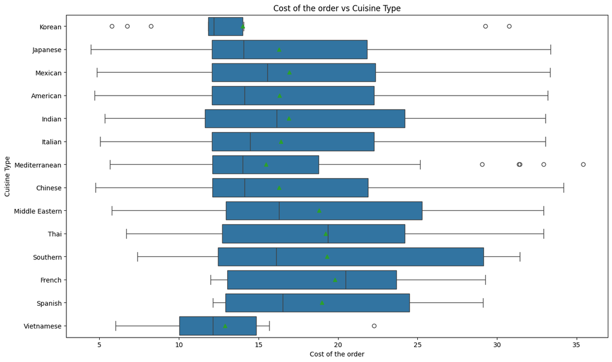

```python
plt.figure(figsize = (15,9))
plt.title('Cost of the order vs Cuisine Type')
plt.ylabel('Cuisine Type')
plt.xlabel('Cost of the order')

# Boxplot is used so we can also see the ouliers present
sns.boxplot(data = data,y = 'cuisine_type',x = 'cost_of_the_order',showmeans = True);
```

```python
# Find the the mean cost of each of the cuisine
avg_cost_df = data.groupby(['cuisine_type'])['cost_of_the_order'].mean().reset_index().sort_values(by = 'cost_of_the_order',ascending = False).reset_index(drop = True)
avg_cost_df
```

|  | cuisine_type | cost_of_the_order |
| --- | --- | --- |
| 0 | French | 19.794 |
| 1 | Southern | 19.301 |
| 2 | Thai | 19.208 |
| 3 | Spanish | 18.994 |
| 4 | Middle Eastern | 18.821 |
| 5 | Mexican | 16.933 |
| 6 | Indian | 16.920 |
| 7 | Italian | 16.419 |
| 8 | American | 16.320 |
| 9 | Chinese | 16.305 |
| 10 | Japanese | 16.305 |
| 11 | Mediterranean | 15.475 |
| 12 | Korean | 14.002 |
| 13 | Vietnamese | 12.883 |

# Let us check how the food preparation time varies for each cuisine type

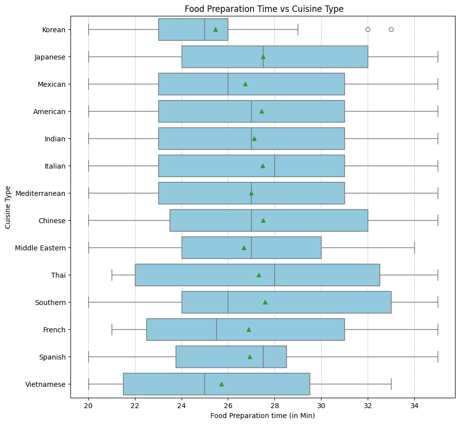

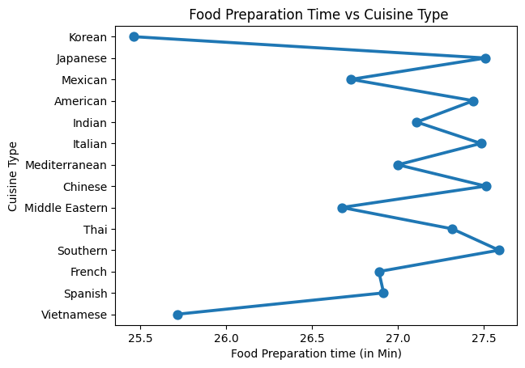

```python
plt.figure(figsize=(10,10))
plt.xlabel("Food Preparation time (in Min)")
plt.ylabel("Cuisine Type")
plt.title(" Food Preparation Time vs Cuisine Type")

# Boxplot
sns.boxplot(data = data,y= 'cuisine_type',x = 'food_preparation_time',showmeans = True,color = 'skyblue');
plt.grid(axis='x', color='gray', linestyle='--', linewidth=0.5, alpha=0.7)
plt.show()

#pointplot
plt.xlabel("Food Preparation time (in Min)")
plt.ylabel("Cuisine Type")
plt.title(" Food Preparation Time vs Cuisine Type")
sns.pointplot(data = data,y= 'cuisine_type',x = 'food_preparation_time',errorbar=None);
plt.show()
```

- Majority of the cuisines have a food preparation time ranging from 20-35 min
- Median time of majority falls in the range 26-28 min
- Korean cuisine has the lowest mean food preparation time followed by Vietnamese
- Southern cuisine has the highest mean food preparation time
- Thai cuisine has the highest IQR.It indicates there is a variability in the preparation times of Thai dishes.ie there may be both simple and complex dishes associated with Thai cuisine

# Cuisine Type vs Delivery Time

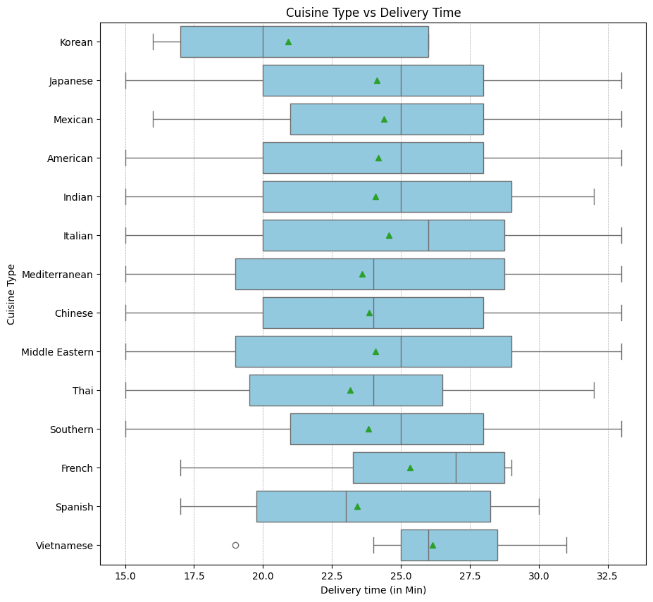

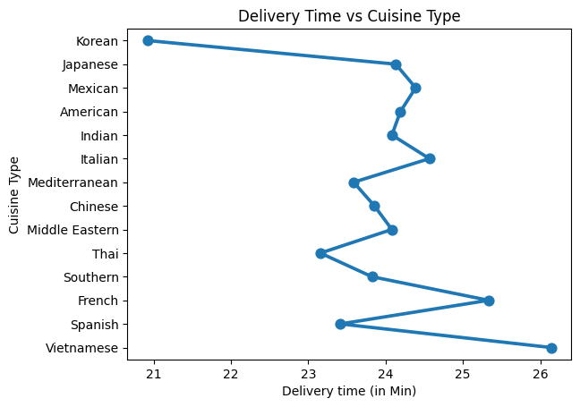

```python
plt.figure(figsize=(10,10))
plt.xlabel("Delivery time (in Min)")
plt.ylabel("Cuisine Type")
plt.title("Cuisine Type vs Delivery Time")

#Boxplot to check whether any outliers are present
sns.boxplot(data = data,y= 'cuisine_type',x = 'delivery_time',showmeans = True,color = 'skyblue');
plt.grid(axis='x', color='gray', linestyle='--', linewidth=0.5, alpha=0.7)
plt.show()


#pointplot
plt.xlabel("Delivery time (in Min)")
plt.ylabel("Cuisine Type")
plt.title("Delivery Time vs Cuisine Type")
sns.pointplot(data = data,y= 'cuisine_type',x = 'delivery_time',errorbar=None);
plt.show()
```

# Observations:

- Mean delivery time of majority of the cuisines except Vietnamese,Korean and French fall in the range 23-25 min
- French cuisine has the highest median delivery time followed by Italian and vietnamese
- Lowest mean delivery time is for Korean cuisine followed by Thai and Spanish

# Let us see the cuisine type preferred during the day of the week

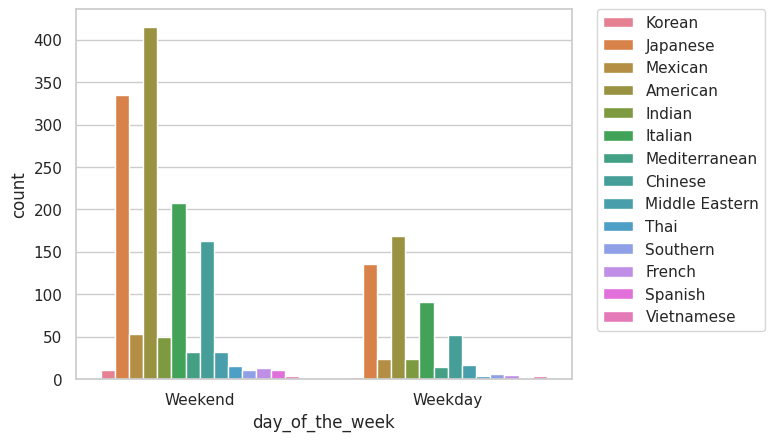

```python
sns.countplot(data = data,x = 'day_of_the_week',hue = 'cuisine_type');
plt.legend(loc='upper left', bbox_to_anchor=(1.05, 1), borderaxespad=0)
plt.show()
```

# Observations:

- For all the cuisines number of orders are greater during the weekends
- American cuisine is the most preferred during both weekday and weekend

# Cuisine Type vs Customers

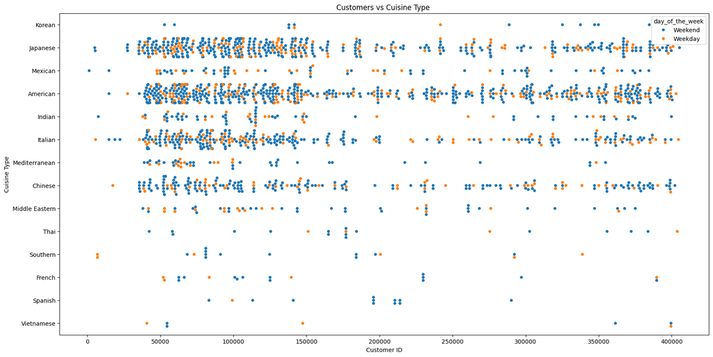

```python
plt.figure(figsize=(20,10))
plt.title('Customers vs Cuisine Type ')
plt.xlabel("Customer ID")
plt.ylabel("Cuisine Type")

sns.swarmplot(data = data,y = 'cuisine_type',x = 'customer_id',hue = 'day_of_the_week');
plt.show()
```

# Observations:

- As seen above majority of the orders are placed by customers with IDs in the range 40000 - 150000.If the customer IDs are sequential IDs ,these customers are the ones who joined the app in the beginning itself
- Cuisine preferred by both the old and new customers are American,Japanese,Italian and Chinese.

# Cuisine type vs Rating

```python
#To calculate the average of the ratings made we need to create a data with only rated values.For this we are deleting the rows with no ratings given.Also changing the type of rating to int
#We are doing the modifications of the rating after copying the original data to another dataframe so that the original dataframe is not manipulated
new = data.copy()
new= new[new['rating'] != 'Not given'].reset_index()
new['rating'] = new['rating'].astype(int)
```

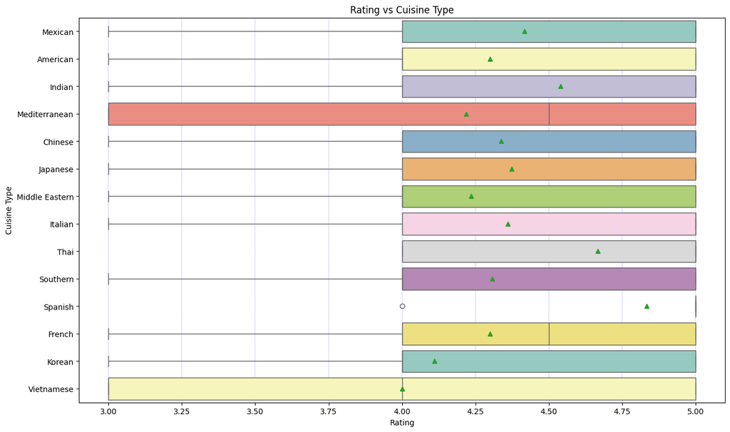

```python
#Boxplot
plt.figure(figsize = (15,9))
plt.title(' Rating vs Cuisine Type ')
plt.ylabel('Cuisine Type')
plt.xlabel('Rating')
sns.boxplot(data = new,x = 'rating',y= 'cuisine_type',showmeans = True,palette = 'Set3');
plt.grid(axis='x', color='blue', linestyle='--', linewidth=0.3, alpha=0.7)
plt.show();
```

```python
cuisine_df= new.groupby(['cuisine_type'])['rating'].mean().reset_index().sort_values(by = 'rating',ascending = False).reset_index(drop = True)
cuisine_df
```

|  | cuisine_type | rating |
| --- | --- | --- |
| 0 | Spanish | 4.833 |
| 1 | Thai | 4.667 |
| 2 | Indian | 4.540 |
| 3 | Mexican | 4.417 |
| 4 | Japanese | 4.374 |
| 5 | Italian | 4.360 |
| 6 | Chinese | 4.338 |
| 7 | Southern | 4.308 |
| 8 | French | 4.300 |
| 9 | American | 4.299 |
| 10 | Middle Eastern | 4.235 |
| 11 | Mediterranean | 4.219 |
| 12 | Korean | 4.111 |
| 13 | Vietnamese | 4.000 |

All the observations made with ratings are solely based on the ratings given by the customers.Orders that are 'not given' rating is not taken into consideration in this plot

# Cuisine type vs Number of Restaurants

```python
#We need to find the number of restaurants available per cuisine
#We create a separate dataframe with only cuisine type and restaurant name
restaurant_df = data[['cuisine_type','restaurant_name']]

#We need to delete the duplicates  as there would be several orders with the same cuisine type and restaurant name
restaurant_df.drop_duplicates(inplace = True)
restaurant_df
```

|  | cuisine_type | restaurant_name |
| --- | --- | --- |
| 0 | Korean | Hangawi |
| 1 | Japanese | Blue Ribbon Sushi Izakaya |
| 2 | Mexican | Cafe Habana |
| 3 | American | Blue Ribbon Fried Chicken |
| 4 | American | Dirty Bird to Go |
| ... | ... | ... |
| 1781 | American | Rye House |
| 1790 | Japanese | Hiroko's Place |
| 1820 | Italian | Frank Restaurant |
| 1840 | American | Sarabeth's West |
| 1877 | American | 'wichcraft |

179 rows × 2 columns

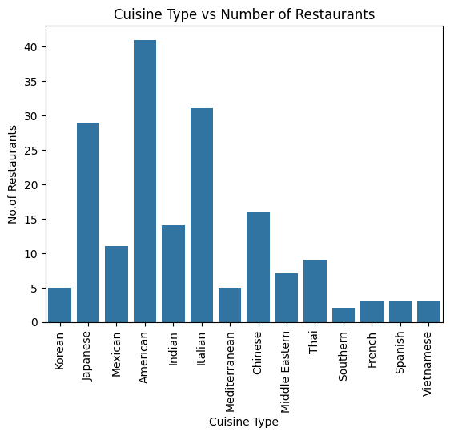

| cuisine_type | count |
| --- | --- |
| American | 41 |
| Italian | 31 |
| Japanese | 29 |
| Chinese | 16 |
| Indian | 14 |
| Mexican | 11 |
| Thai | 9 |
| Middle Eastern | 7 |
| Korean | 5 |
| Mediterranean | 5 |
| French | 3 |
| Spanish | 3 |
| Vietnamese | 3 |
| Southern | 2 |

**dtype:** int64

```python
#Lets plot a graph to find the number of restaurants for each cuisine type
plt.title('Cuisine Type vs Number of Restaurants')
plt.xlabel('Cuisine Type')
plt.ylabel('No.of Restaurants')
sns.countplot(data = restaurant_df,x = 'cuisine_type')
plt.xticks(rotation =90);
plt.show()
restaurant_df['cuisine_type'].value_counts()
```

# Cost of the order vs rating

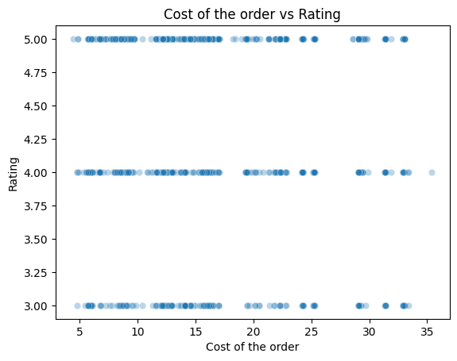

```python
plt.title('Cost of the order vs Rating')
plt.xlabel('Cost of the order')
plt.ylabel('Rating')
#To make the overlapping points more visible we have added alpha to the plot
sns.scatterplot(data = new,x= 'cost_of_the_order',y= 'rating',alpha = .3);
plt.show()
```

# Observations:

- The number of ratings decrease with increase in the cost of the order because as stated above number of orders decrease with increase in cost of the orders
- Orders with rating for 4 has the highest cost
- It can be seen that beyond the cost of 33 it is either rating 3 or 4 and not 5.
- Many of the orders in the lower range of cost has rating 5.Number of rating 5 decreases with increase in the cost.
- This shows customers don't prefer high priced food

# Let us check whether any correlation exists between cost of the order ,delivery time and food Preparation time

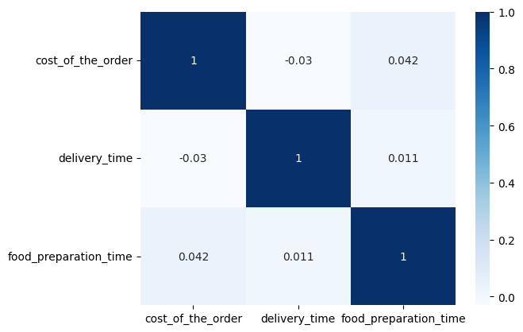

```python
sns.heatmap(data = data[['cost_of_the_order','delivery_time','food_preparation_time']].corr(),annot = True,cmap = 'Blues');
```

Observations: There doesn't seem to be any strong correlation between delivery time,food preparation time and cost of order

# Let us see whether there is any correlation between rating,cost of the order,delivery time and preparation time

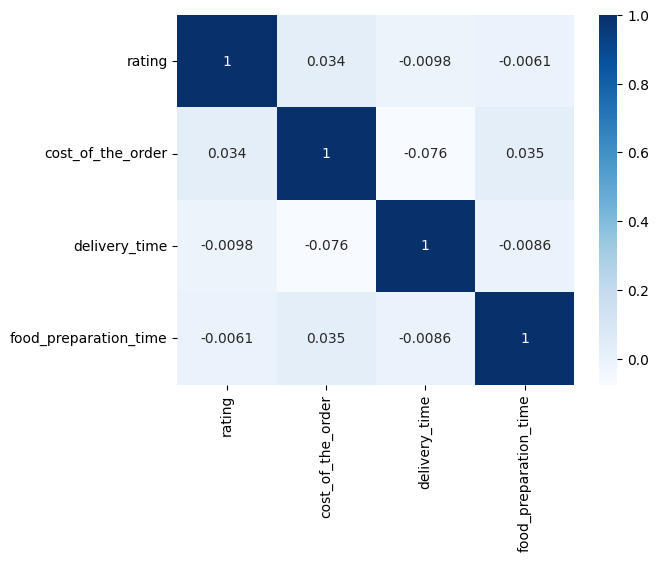

```python
#Here we have used the altered dataframe in which rating has been converted to int and the rows containing the rating "Not given" was removed
sns.heatmap(data = new[['rating','cost_of_the_order','delivery_time','food_preparation_time']].corr(),annot = True,cmap = 'Blues');
```

# Observations:

There is no strong positive or negative correlation between rating,cost of the order,delivery time and preparation time

# Cost of the order vs Food Preparation Time

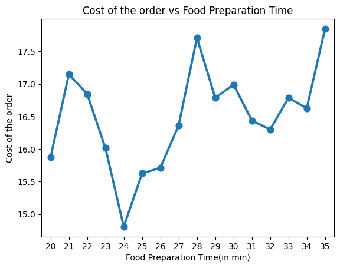

```python
plt.title('Cost of the order vs Food Preparation Time')
plt.ylabel('Cost of the order')
plt.xlabel('Food Preparation Time(in min)')
sns.pointplot(data = data,y= 'cost_of_the_order',x = 'food_preparation_time',errorbar=None);
```

Observations:

- The plot shows how the cost of the order varies with different food preparation times. It appears to fluctuate, with some notable peaks and valleys.
- There are some peaks at 28 and 35,which shows that foods taking more time to prepare are more expensive.But it is not linear
- Also there is a dip at 24 min,indicating orders with this preparation time tend to be less expensive
- However there is no strong correlation between cost of the order and food preparation time

# Cost of the order vs Delivery Time

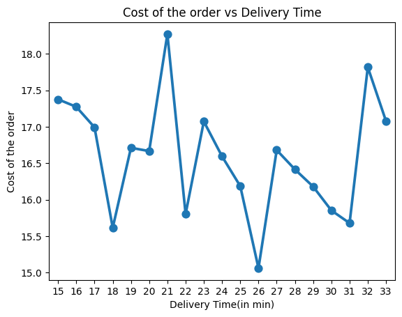

```python
plt.title('Cost of the order vs Delivery Time')
plt.ylabel('Cost of the order')
plt.xlabel('Delivery Time(in min)')
sns.pointplot(data = data,y= 'cost_of_the_order',x = 'delivery_time',errorbar=None);
```

# Observations:

- The plot shows how the cost of the order varies with different delivery time. It appears to fluctuate, with some notable peaks and valleys.
- Highest mean cost is at around 21 minutes,which shows some of the foods that are delivered around 21 minutes tend to be costlier.Cost may be dependent on several other factors like cuisine type,restaurant etc
- A dip in the cost is observed at 26 min,indicating food delivered around this time tend to be cheaper
- However there is no strong correlation between cost of the order and delivery time

# Lets check whether there is any relation between day of the week and the cost of the order

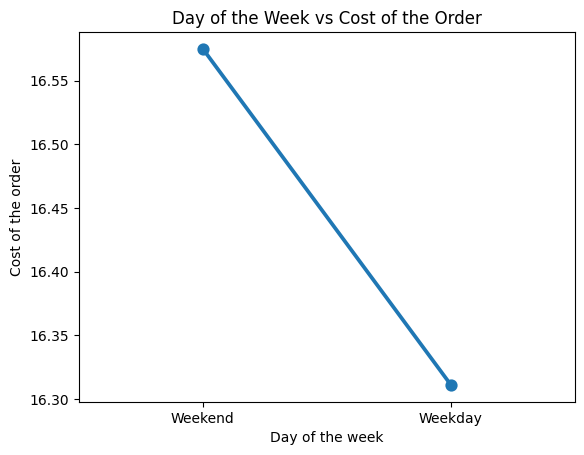

```python
plt.xlabel("Day of the week")
plt.ylabel("Cost of the order")
plt.title("Day of the Week vs Cost of the Order")
sns.pointplot(data = data,y = 'cost_of_the_order',x = 'day_of_the_week',errorbar=None);
```

# Observations :

- Average cost of the order is slightly higher during the weekends comapred to Weekdays

# Delivery_time vs day of the week

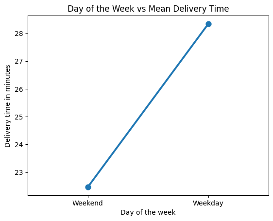

```python
plt.xlabel("Day of the week")
plt.ylabel("Delivery time in minutes")
plt.title("Day of the Week vs Mean Delivery Time")
sns.pointplot(data = data,y = 'delivery_time',x = 'day_of_the_week',errorbar=None);
```

```python
df = data.groupby(['day_of_the_week'])['delivery_time'].mean()
df
```

| day_of_the_week | delivery_time |
| --- | --- |
| Weekday | 28.340 |
| Weekend | 22.470 |

**dtype:** float64

# Observations:

- Delivery _time is greater during the Weekdays compared to the Weekend.
- Mean delivery time during Weekday is 28.3 min
- Mean delivery time during Weekend is 22.4 min
- Even though the no of orders is greater on weekend,delivery_time is greater on weekday

# Day of the Week vs Food Preparation Time

[figure not shown]

```python
plt.xlabel("Day of the week")
plt.ylabel("Food Preparation Time (min)")
plt.title("Day of the Week vs Food Preparation Time")
sns.pointplot(data = data,y = 'food_preparation_time',x = 'day_of_the_week',errorbar=None);
```

# Observations:

- Mean food preparation time is slightly higher on Weekend compared to weekdays

# Day of the week vs Rating

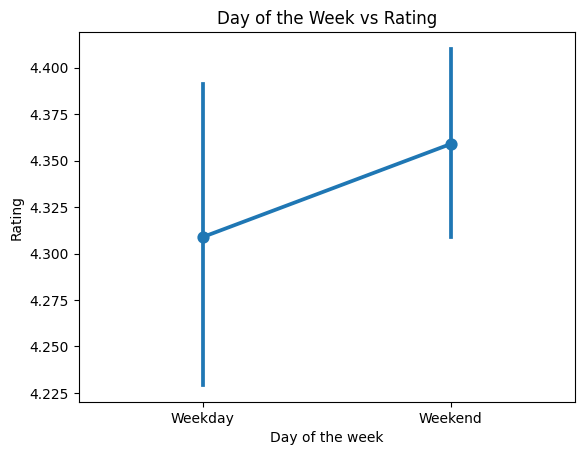

```python
plt.xlabel("Day of the week")
plt.ylabel("Rating")
plt.title("Day of the Week vs Rating")
sns.pointplot(data = new,y= 'rating',x = 'day_of_the_week');
```

# Observations:

1. Mean rating is slightly higher on weekend compared to weekdays

# Rating vs Food Preparation Time

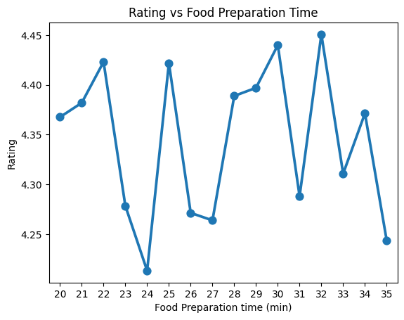

```python
plt.ylabel("Rating")
plt.xlabel("Food Preparation time (min)")
plt.title("Rating vs Food Preparation Time")
sns.pointplot(data = new,x ='food_preparation_time',y = 'rating',errorbar = None);
```

# Observation:

- There is no strong positive or negative correlation between rating and Food preparation time.
- The plot shows how the rating varies with different food preparation time. It appears to fluctuate, with some notable peaks and valleys.
- Highest mean rating was recorded at around 32 min.Beyond this time a dip in the rating is noted with a sharp dip at 35 min.Shwoing customers a less satisfied as the food preparation time goes beyond 32 min
- A very sharp dip in avg rating is observed around 24 min,indicating some of the orders prepared during this time was poorly rated by the customers

# Rating vs Delivery Time

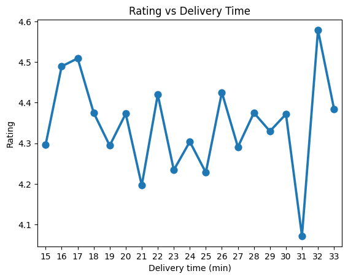

```python
plt.ylabel("Rating")
plt.xlabel("Delivery time (min)")
plt.title("Rating vs Delivery Time")
sns.pointplot(data = new,x='delivery_time',y= 'rating',errorbar= None);
```

Observations:

- There is no clear linear correlation between delivery time and rating. The ratings fluctuate across different delivery times, suggesting that delivery time alone may not be the sole factor influencing customer ratings.
- There is a sharp dip at 31 minutes.It needs to checked further to see what is the cause behind such a sharp dip

# Total time taken vs Rating

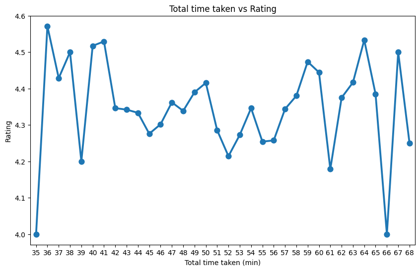

```python
# let us see how the total time taken affects the ratings given
plt.figure(figsize = (10,6))
plt.xlabel("Total time taken (min)")
plt.ylabel("Rating")
plt.title("Total time taken vs Rating")

new['total_time'] = new['food_preparation_time'] + new['delivery_time']
sns.pointplot(data = new,x='total_time',y = 'rating',errorbar = None);
```

## Observations:

- Ratings generally vary from 4 - 4.5 across the entire time
- There is wide range of rating variability at 35min and 66 min,indicating some customers were extremely satisfied while some are not
- Around 40-60 min the ratings are comparatively stable,with no high variations which indicates the customers hav consistent experience in this range

### **Question 13:** The company wants to provide a promotional offer in the advertisement of the restaurants. The condition to get the offer is that the restaurants must have a rating count of more than 50 and the average rating should be greater than 4. Find the restaurants fulfilling the criteria to get the promotional offer. [3 marks]

```python
#To calculate the average of the ratings made we need to create a data with only rated values.For this we are deleting the rows with no ratings given.Also changing the type of rating to int
#We are doing the modifications of the rating after copying the original data to another dataframe so that the original dataframe is not manipulated
new_data = data.copy()
new_data = new_data[new_data['rating'] != 'Not given'].reset_index()
new_data['rating'] = new_data['rating'].astype(int)
```

```python
df = new_data['restaurant_name'].value_counts().reset_index()
df.columns = ['restaurant_name','rating_count']
df = df.loc[df['rating_count']>50]
df
```

|  | restaurant_name | rating_count |
| --- | --- | --- |
| 0 | Shake Shack | 133 |
| 1 | The Meatball Shop | 84 |
| 2 | Blue Ribbon Sushi | 73 |
| 3 | Blue Ribbon Fried Chicken | 64 |

```python
rating_df = new_data.groupby(['restaurant_name'])['rating'].mean().reset_index()
rating_df
```

|  | restaurant_name | rating |
| --- | --- | --- |
| 0 | 'wichcraft | 5.000 |
| 1 | 12 Chairs | 4.500 |
| 2 | 5 Napkin Burger | 4.000 |
| 3 | 67 Burger | 5.000 |
| 4 | Amma | 4.500 |
| ... | ... | ... |
| 151 | Zero Otto Nove | 4.000 |
| 152 | brgr | 3.000 |
| 153 | da Umberto | 5.000 |
| 154 | ilili Restaurant | 4.154 |
| 155 | indikitch | 4.500 |

156 rows × 2 columns

```python
#Merging dataframes to get a list of restaurants with avg  rating >4 and no of ratings >50
pd.merge(df,rating_df,on='restaurant_name',how = 'inner')
```

|  | restaurant_name | rating_count | rating |
| --- | --- | --- | --- |
| 0 | Shake Shack | 133 | 4.278 |
| 1 | The Meatball Shop | 84 | 4.512 |
| 2 | Blue Ribbon Sushi | 73 | 4.219 |
| 3 | Blue Ribbon Fried Chicken | 64 | 4.328 |

#### Observations:

The restaurants fulfilling the criteria are:

- Shake Shack
- The Meatball shop
- Blue Ribbon Sushi
- Blue Ribbon Fried Chicken

### **Question 14:** The company charges the restaurant 25% on the orders having cost greater than 20 dollars and 15% on the orders having cost greater than 5 dollars. Find the net revenue generated by the company across all orders. [3 marks]

```python
#define a function to calculate the revenue charged
def revenue(cost):
  if cost > 20:
    return cost * .25
  elif cost > 5:
    return cost * .15
  else:
    return 0
```

```python
#add the new column which would store the revenue imposed by the company on each orders
data['revenue_charged'] = data['cost_of_the_order'].apply(revenue)
```

```python
print("Net revenue generated by the company across all orders = ",data['revenue_charged'].sum())
```

```
Net revenue generated by the company across all orders =  6166.303
```

### **Question 15:** The company wants to analyze the total time required to deliver the food. What percentage of orders take more than 60 minutes to get delivered from the time the order is placed? (The food has to be prepared and then delivered.) [2 marks]

```python
# Calculate the total time first
data['total_time'] = data['food_preparation_time'] + data['delivery_time']

#Find the orders with total time greater than 60 min
num_of_orders = data.loc[data['total_time'] >60]
print("Number of orders with total time greater than 60 minutes = ",num_of_orders.shape[0])
print("Total number of orders = ",data.shape[0]);
print("Percentage of orders that takes more than 60 minutes to get delivered from the time the order is placed is =", (num_of_orders .shape[0]/data.shape[0]*100),"%")
```

```
Number of orders with total time greater than 60 minutes =  200
Total number of orders =  1898
Percentage of orders that takes more than 60 minutes to get delivered from the time the order is placed is = 10.537407797681771 %
```